# Project2

Marthinus Basson

9/6/2018

During this project the problem addressed is to predict which president said a sentence during the State of the Nation adderess by using historical data. The data came as text files contating the entire speech from each presedient in the respective year the sona was made.

To address this problem, a neural network should be created to have a sentence as an input and the respective president who said that senctence as the output.

First the text data is imported and the president and respective year are extracted from the text name. Each sentence is given an unique Id and each president is given a unique id. Then the sentences are unnested to words, the filler words are removed. First a bag of words are created to analyse a bag of words model with the data.

##Bag Of Words

```r
library(tidyverse)
library(tidytext)
library(data.table)
```

```r
library(ggplot2)
library(lubridate)
library(stringr)

# point to where the txt files are
txt_files <- list.files("sona")

sona <- data.frame(filename = as.character(), speech = as.character())
for(i in txt_files){
  file_name <- paste0("sona/", i)

  # import text as single character string (can also read.table but the "seperator" causes problems)
  this_speech <- readChar(file_name,
                          nchars = file.info(file_name)$size)

  # make data frame with metadata (filename contains year and pres) and speech
  this_sona <- data.frame(filename = i, speech = this_speech, stringsAsFactors = FALSE)

  # make a single dataset
  sona <- rbind(sona, this_sona)
}


#extract the year from each file name
sona$year <- str_sub(sona$filename, start = 1, end = 4)
#extract the president name from each file name(looking at where the word has a capital letter)
pres_name<-str_extract(sona$filename,'[A-Z][a-z]+')

#create dataset where with president name,year of speech and the text file
new_sona<-cbind(pres_name,sona)%>%select(-filename)
#create data table with speech unnested as sentences
tidy_sona <- data.table(new_sona %>% unnest_tokens(text, speech, token = "sentences"))
pres_id<-data.table(pres_name = unique(new_sona$pres_name),ID =0) #insert ID column
#fill id column with unique Id for each president
  for(k in 1:length(pres_id$pres_name)){

    pres_id[k,]$ID<-k

  }
#create dataset with unique ID of each president
tidy_sona<-merge(tidy_sona,pres_id)
tidy_sona$sentID<-0
#fill dataset with unique id for each sentence
  for(k in 1:length(tidy_sona$sentID)){

    tidy_sona[k,]$sentID<-k

  }
#unnest sentences to word
word_sona<-tidy_sona%>%select('ID',everything())%>%unnest_tokens(word,text,token = 'words')%>%filter(!word %in% stop_words$word, str_detect(word, "[a-z]"))
word_bag<-word_sona%>% group_by(word)%>%count()%>%arrange(desc(n))%>%top_n(200, wt = n)%>%select(-n)

#create data set where is infdicated the number of times a word is used within a sentence
sona_tdf <- word_sona%>%
  inner_join(word_bag) %>%
  group_by(sentID,word) %>%
  count() %>%
  group_by(sentID) %>%
  mutate(total = sum(n)) %>%
  ungroup()
#create a bag of words for each sentence and each president's sona
bag_o_words <- sona_tdf %>%
  select(sentID,word,n) %>%
  spread(key = word, value = n, fill = 0) %>%
  left_join(tidy_sona %>% select(sentID,ID)) %>%
  select(sentID, ID, everything())
#remove 70% of bag of words matrix as training for neural network
training_ids <- bag_o_words %>%
  group_by(ID) %>%
  sample_frac(0.7) %>%
  ungroup() %>%
  select(sentID)

#transform to data.table for faster processing and computation when doing joins
bag_o_words<-data.table(bag_o_words)
training_ids<-data.table(training_ids)
#set the unique key for each data table
setkey(bag_o_words,sentID)
setkey(training_ids,sentID)
#join training bag of words with their respective ID's
training_sona <-bag_o_words[training_ids]%>%select(-sentID)
test_sona<-bag_o_words[!training_ids]%>%select(-sentID)
```

A neural network model is created to fit the bag of words model data. The bag of words data is split in to test and train data. ##Neural Net

```r
library(keras)
#create training matrices from the bag of words created
x_train <- as.matrix(training_sona %>% select(-ID), ncol = 9697)
y_train <-as.matrix(1*(training_sona %>% select(ID)), ncol = 1)

#create the test matices from the bag of words
x_test <- as.matrix(test_sona %>% select(-ID), ncol = 9698)
y_test <- as.matrix(test_sona %>% select(ID), ncol = 1)
#hot encode the results matrix as it ranges from 1-6 for each president
y_train<-to_categorical(y_train,7)
y_test<-to_categorical(y_test,7)
#
#create the neural network model using keras
model <- keras_model_sequential()

model %>%
  layer_dense(units = 35,                  # number of neurons in the hidden layer
              input_shape = c(9697)) %>%
  layer_dense(units = 35,                  # number of neurons in the hidden layer
              input_shape = c(9697)) %>%# dimension of input array
  layer_activation('relu') %>%             # use a rectified linear unit as an activation function in the hidden layer
  layer_dense(units = 7) %>%               # adds an output layer to the network
  layer_activation('sigmoid')

model %>% compile(
  optimizer = 'rmsprop',
  loss = 'binary_crossentropy',
  metrics = c('accuracy')
)
```

The model is fitted with the train data and to test the validity, it is evaluated with test data.

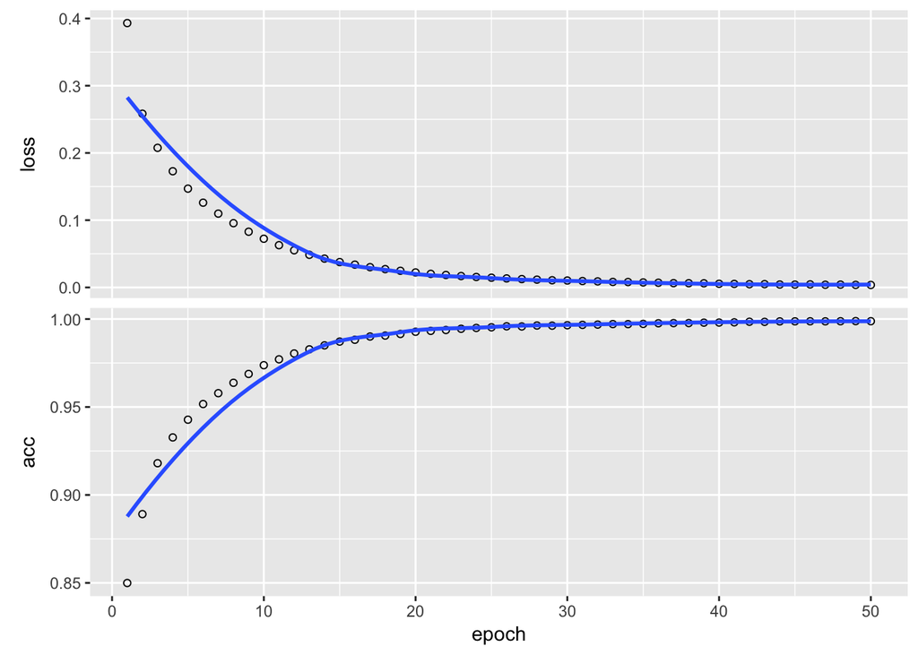

```r
model %>% fit(x_train, y_train, epochs = 50, batch_size = 35) %>% plot() #fit the model
```

```r
 model %>% evaluate(x_test, y_test, batch_size=32, verbose = 1)#test the model using out of sample data
```

```
## $loss
## [1] 1.014205
##
## $acc
## [1] 0.8789556
```

```r
model %>% predict_classes(x_test) #predict the presidents who said a the sentence contained in the test data
```

```
##    [1] 1 2 3 3 2 2 5 1 1 2 2 3 2 2 2 3 3 1 2 3 1 2 1 4 3 3 3 3 2 4 2 1 3 3
##   [35] 4 4 4 1 4 3 4 3 1 3 1 1 4 3 3 3 3 5 3 3 5 4 1 4 3 1 1 1 3 1 3 4 3 1
##   [69] 4 3 1 1 3 1 3 2 1 3 1 3 3 4 4 4 1 1 1 3 3 1 4 3 4 3 1 1 1 1 1 3 1 3
##  [103] 1 1 1 1 3 4 3 1 1 3 1 1 3 4 1 3 3 3 1 1 2 1 4 1 1 3 1 4 3 4 1 1 1 1
##  [137] 1 1 1 3 2 3 3 1 3 3 3 3 3 3 1 1 1 1 4 1 1 1 1 1 4 4 3 4 4 1 4 3 3 3
##  [171] 1 1 4 1 4 4 1 3 1 4 1 3 1 4 1 1 1 1 1 1 4 4 1 1 4 1 1 1 1 5 1 3 1 1
##  [205] 4 1 1 1 3 4 6 4 3 1 1 5 1 1 1 1 1 3 3 1 4 5 3 1 1 1 1 4 3 3 4 1 1 1
##  [239] 1 1 1 4 3 1 1 4 3 4 1 1 3 1 1 3 1 1 1 1 4 4 4 1 3 4 1 3 4 1 3 1 4 4
##  [273] 3 4 1 4 5 3 3 4 4 1 1 1 3 1 1 1 1 1 1 1 1 1 1 3 1 1 4 3 5 3 1 3 1 4
##  [307] 3 3 1 1 1 1 1 6 4 1 1 1 1 1 3 1 3 1 4 3 4 3 3 1 1 3 1 3 4 1 4 6 1 1
##  [341] 1 3 1 1 1 1 1 1 4 1 1 3 1 1 3 1 3 1 1 1 3 1 1 1 1 6 1 1 1 1 5 4 1 3
##  [375] 1 1 3 3 3 3 3 3 1 3 4 1 4 5 3 1 4 1 4 1 4 3 1 3 1 3 3 1 1 4 3 3 3 3
##  [409] 3 1 1 3 3 1 3 1 4 1 1 3 3 1 1 1 3 3 1 4 4 3 3 1 1 1 3 4 1 4 4 3 1 1
##  [443] 1 1 3 1 1 1 3 3 1 5 1 3 3 5 1 3 3 1 5 3 1 3 4 3 1 3 1 3 1 3 1 4 1 3
##  [477] 4 1 3 1 3 1 5 1 1 1 4 1 1 1 1 1 4 1 5 1 3 3 3 4 1 1 1 2 1 1 1 3 1 1
```

[output cut: 50 more lines]

```r
sent_sona<-word_sona%>%group_by(sentID)
sent_sona<-sent_sona%>%group_by(sentID)%>%summarise(sent = paste(word,collapse = ","))

sent_bag<-sent_sona%>% group_by(sent)%>%count()%>%arrange(desc(n))%>%top_n(200, wt = n)%>%select(-n)
sona_sent <- sent_sona%>%
  inner_join(sent_bag) %>%
  group_by(sentID,sent) %>%
  count() %>%
  group_by(sentID) %>%
  mutate(total = sum(n)) %>%
  ungroup()
 bag_o_sent <- sona_sent %>%
  select(sentID,sent,n) %>%
  spread(key = sent, value = n, fill = 0) %>%
  left_join(tidy_sona %>% select(sentID,ID)) %>%
  select(sentID, ID, everything())
 training_sentences <- bag_o_sent %>%
  group_by(ID) %>%
  sample_frac(0.7) %>%
  ungroup() %>%
  select(sentID)

#transform to data.table for faster processing and computation when doing joins
bag_o_sent<-data.table(bag_o_sent)
training_sentences<-data.table(training_sentences)
#set the unique key for each data table
setkey(bag_o_sent,sentID)
setkey(training_sentences,sentID)
#join training bag of words with their respective ID's
training_sona_sent <-bag_o_sent[training_sentences]%>%select(-sentID)
test_sona_sent<-bag_o_sent[!training_sentences]%>%select(-sentID)
```

The neural network model for the sentence model is created. ##Nueral Net sentences

```r
library(keras)
#create training matrices from the bag of words created
x_train_sent <- as.matrix(training_sona_sent %>% select(-ID), ncol = 7056)
y_train_sent <-as.matrix(1*(training_sona_sent %>% select(ID)), ncol = 1)

#create the test matices from the bag of words
x_test_sent <- as.matrix(test_sona_sent %>% select(-ID), ncol = 7056)
y_test_sent <- as.matrix(test_sona_sent %>% select(ID), ncol = 1)
#hot encode the results matrix as it ranges from 1-6 for each president
y_train_sent<-to_categorical(y_train_sent,7)
y_test_sent<-to_categorical(y_test_sent,7)
#
#create the neural network model using keras
model_2 <- keras_model_sequential()

model_2 %>%
  layer_dense(units = 35,                  # number of neurons in the hidden layer
              input_shape = c(7054)) %>%
  layer_dense(units = 35,                  # number of neurons in the hidden layer
              input_shape = c(7054)) %>%# dimension of input array
  layer_activation('relu') %>%             # use a rectified linear unit as an activation function in the hidden layer
  layer_dense(units = 7) %>%               # adds an output layer to the network
  layer_activation('softmax')

model_2 %>% compile(
  optimizer = 'rmsprop',
  loss = 'binary_crossentropy',
  metrics = c('accuracy')
)
```

##Neural Net Sent

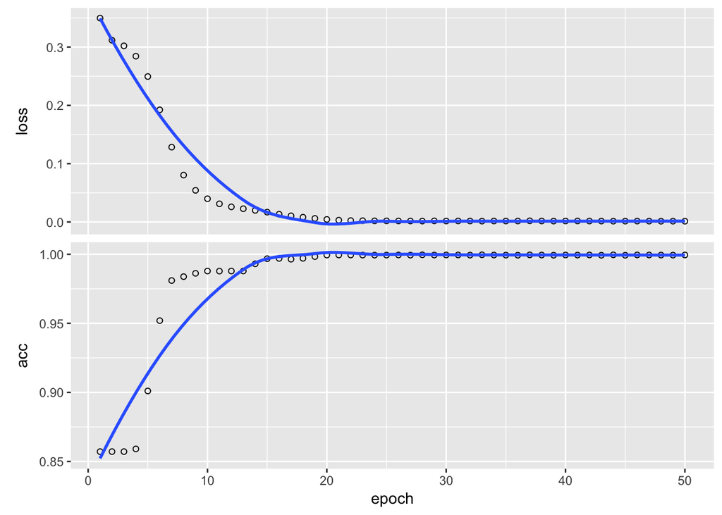

```r
model_2 %>% fit(x_train_sent, y_train_sent, epochs = 50, batch_size = 35) %>% plot() #fit the model
```

```r
model_2 %>% evaluate(x_test_sent, y_test_sent, batch_size=32, verbose = 1)#test the model using out of sample data
```

```
## $loss
## [1] 1.881149
##
## $acc
## [1] 0.7312801
```

```r
model_2 %>% predict_classes(x_test_sent) #predict the presidents who said a the sentence contained in the test data
```

```
##    [1] 2 2 2 2 2 2 2 2 2 2 2 2 2 2 2 2 2 2 2 2 2 2 2 2 2 2 2 2 2 2 2 2 2 2
##   [35] 2 2 2 2 2 2 2 2 2 2 2 2 2 2 2 2 2 2 2 2 2 2 2 2 2 2 2 2 2 2 2 2 2 2
##   [69] 2 2 2 2 2 2 2 2 2 2 2 2 2 2 2 2 2 2 2 2 2 2 2 2 2 2 2 2 2 2 2 2 2 2
##  [103] 2 2 2 2 2 2 2 2 2 2 2 2 2 2 2 2 2 2 2 2 2 2 2 2 2 2 2 2 2 2 2 2 2 2
##  [137] 2 2 2 2 2 2 2 2 2 2 2 2 2 2 2 2 2 2 2 2 2 2 2 2 2 2 2 2 2 2 2 2 2 2
##  [171] 2 2 2 2 2 2 2 2 2 2 2 2 2 2 2 2 2 2 2 2 2 2 2 2 2 2 2 2 2 2 2 2 2 2
##  [205] 2 2 2 2 2 2 2 2 2 2 2 2 2 2 2 2 2 2 2 2 2 2 2 2 2 2 2 2 2 2 2 2 2 2
##  [239] 2 2 2 2 2 2 2 2 2 2 2 2 2 2 2 2 2 2 2 2 2 2 2 2 2 2 2 2 2 2 2 2 2 2
##  [273] 2 2 2 2 2 2 2 2 2 2 2 2 2 2 2 2 2 2 2 2 2 2 2 2 2 2 2 2 2 2 2 2 2 2
##  [307] 2 2 2 2 2 2 2 2 2 2 2 2 2 2 2 2 2 2 2 2 2 2 2 2 2 2 2 2 2 2 2 2 2 2
##  [341] 2 2 2 2 2 2 2 2 2 2 2 2 2 2 2 2 2 2 2 2 2 2 2 2 2 2 2 3 2 2 2 2 2 2
##  [375] 2 2 2 2 2 2 2 2 2 2 2 2 2 2 2 2 2 2 2 2 2 2 2 2 2 2 2 2 2 2 2 2 2 2
##  [409] 2 2 2 2 2 2 2 2 2 2 2 2 2 2 2 2 2 2 2 2 2 2 2 2 2 2 2 2 2 2 2 2 2 2
##  [443] 2 2 2 2 2 2 2 2 2 2 2 2 2 2 2 2 2 2 2 2 2 2 2 2 2 2 2 2 2 2 2 2 2 2
##  [477] 2 2 2 2 2 2 2 2 2 2 2 2 2 2 2 2 2 2 2 2 2 2 2 2 2 2 2 2 2 2 2 2 2 2
```

[output cut: 50 more lines]

Sentiment analysis is done one the words of the sona to see which sona wsa positive and negative. ##Sentiment Analysis

```r
sent_sona<-word_sona%>%left_join(get_sentiments('bing'))%>%select(word,sentiment,everything())%>%
  mutate(sentiment = ifelse(is.na(sentiment), "neutral", sentiment))
```

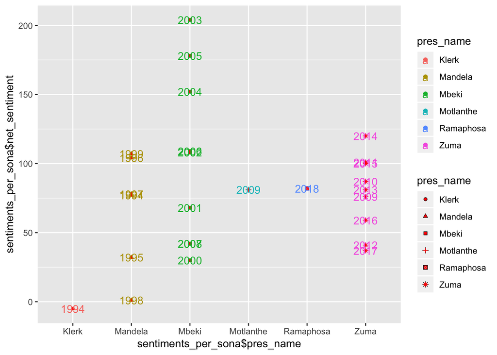

```r
sentiments_per_sona <- sent_sona %>%
  group_by(year,pres_name) %>%
  summarize(net_sentiment = (sum(sentiment == "positive") - sum(sentiment == "negative")))

ggplot(sentiments_per_sona, aes(sentiments_per_sona$pres_name, sentiments_per_sona$net_sentiment,shape=pres_name, color=pres_name)) +
  geom_point() +
  geom_point(data = sentiments_per_sona, aes(sentiments_per_sona$pres_name), colour = 'red', size = 1) + geom_text(label = sentiments_per_sona$year)+
  guides(color = guide_legend(order=1),
         size = guide_legend(order=2),
         shape = guide_legend(order=3))
```

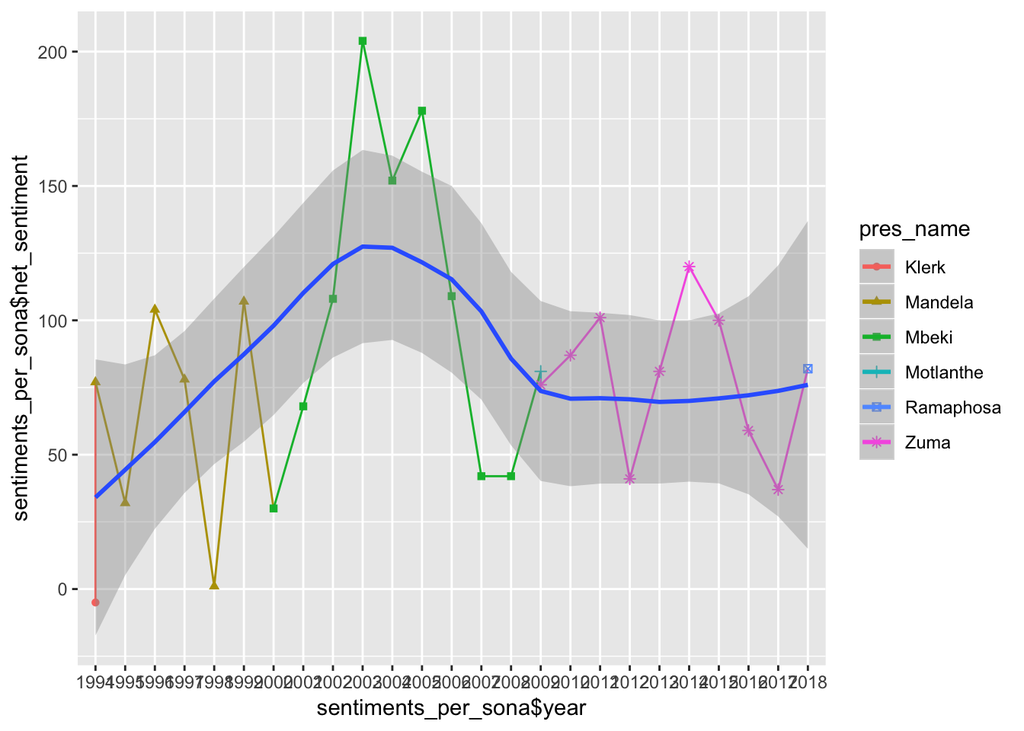

```r
ggplot(sentiments_per_sona, aes(sentiments_per_sona$year, sentiments_per_sona$net_sentiment,shape=pres_name, color=pres_name,group = 1)) +
  geom_path() +
  geom_point()+
  geom_smooth()
```

```r
#Identify word within each sona that points to current state of the nation with words that point to future or past
cur_sent_sona <- word_sona %>%
  left_join(get_sentiments("bing")) %>% # add sentiments (pos or neg)
  select(word,sentiment,everything()) %>%
  mutate(sentiment = ifelse(word == "will", NA, sentiment))%>%
    mutate(sentiment = ifelse(is.na(sentiment), "neutral", sentiment))
```

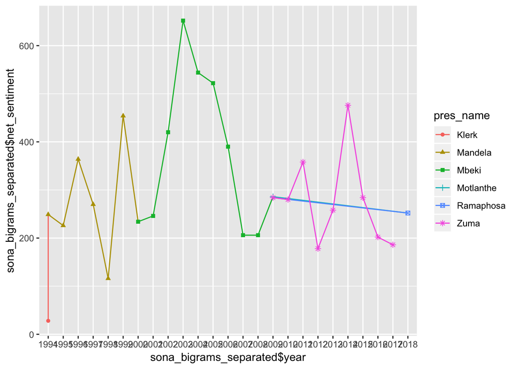

```r
sentiments_per_sona <- sent_sona %>%
  group_by(year,pres_name) %>%
  summarize(net_sentiment = (sum(sentiment == "positive") - sum(sentiment == "negative")))



sona_bigrams_separated  <- new_sona %>%
  filter(!str_detect(speech, "^RT")) %>%
  unnest_tokens(bigram, speech, token = "ngrams", n = 2) %>%
  separate(bigram, c("word1", "word2"), sep = " ")

sona_bigrams_separated<-sona_bigrams_separated%>%
  left_join(get_sentiments('bing'),by = c(word1 = 'word'))%>%
  rename(sentiment1 =sentiment)%>%mutate(sentiment1 = ifelse(is.na(sentiment1), "neutral", sentiment1))%>%
  left_join(get_sentiments('bing'),by = c(word2 = 'word'))%>%
  rename(sentiment2 = sentiment)%>%
  mutate(sentiment2 = ifelse(is.na(sentiment2), "neutral", sentiment2))%>%
  select(word1,word2,sentiment1,sentiment2,everything())

negation_words <- c("not", "no", "never", "without")

sona_bigrams_separated <- sona_bigrams_separated%>%

    # create a variable that is the opposite of sentiment2
    mutate(opp_sentiment2 = recode(sentiment2, "positive" = "negative",
                                 "negative" = "positive",
                                 "neutral" = "neutral")) %>%

    # reverse sentiment2 if word1 is a negation word
    mutate(sentiment2 = ifelse(word1 %in% negation_words, opp_sentiment2, sentiment2)) %>%

    # remove the opposite sentiment variable, which we don't need any more
    select(-opp_sentiment2)

sona_bigrams_separated <- sona_bigrams_separated %>%
  mutate(net_sentiment = (sentiment1 == "positive") + (sentiment2 == "positive") -
              (sentiment1 == "negative") - (sentiment2 == "negative")) %>%
  unite(bigram, word1, word2, sep = " ", remove = FALSE)

sona_bigrams_separated<-sona_bigrams_separated%>%group_by(pres_name,year)%>%summarise(net_sentiment=sum(net_sentiment))

ggplot(sona_bigrams_separated, aes(sona_bigrams_separated$year, sona_bigrams_separated$net_sentiment,shape=pres_name, color=pres_name,group = 1)) +
  geom_path() +
  geom_point()
```

And a analysis was done to select words that points to if the sona focuses more on what will be done and not the current state of the nation. This points to if the current state of the nation is postive or negative:

```r
fut_negation_words <- c('to',"will","going","to ",'To')
cur_sent_sona <- word_sona %>%
  left_join(get_sentiments("bing")) %>% # add sentiments (pos or neg)
  select(word,sentiment,everything()) %>%
  mutate(sentiment = ifelse(word== c('will','to'),"negative",sentiment))%>%
    mutate(sentiment = ifelse(is.na(sentiment), "neutral", sentiment))
```

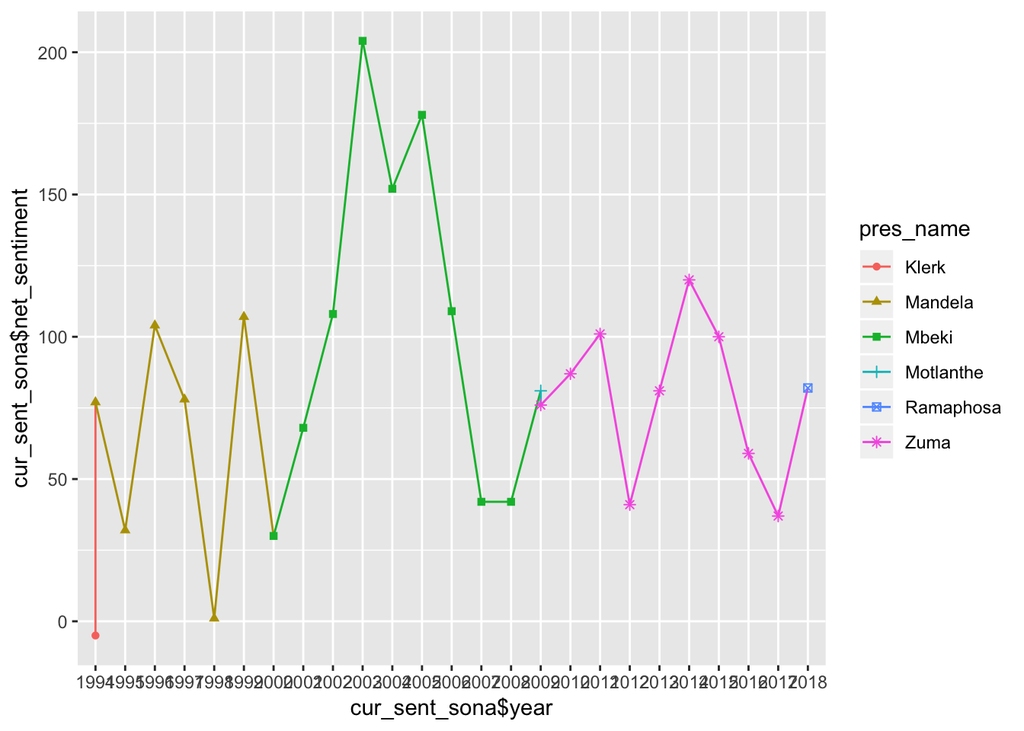

```r
  cur_sent_sona<- cur_sent_sona %>%
  group_by(year,pres_name) %>%
  summarize(net_sentiment = (sum(sentiment == "positive") - sum(sentiment == "negative")))

  ggplot(cur_sent_sona, aes(cur_sent_sona$year,cur_sent_sona$net_sentiment,shape=pres_name, color=pres_name,group = 1)) +
  geom_path() +
  geom_point()
```

```r
library(gridExtra)
gdp<-data.table(c(1960, 1961    ,1962   ,1963,  1964,   1965,   1966,   1967,   1968,   1969,   1970,   1971,   1972,   1973,   1974    ,1975,  1976,   1977    ,1978,1979  ,1980,  1981,   1982,   1983,   1984,   1985,   1986,   1987,   1988,   1989,   1990,   1991,   1992    ,1993,  1994,   1995    ,1996   ,1997,  1998,   1999,   2000,   2001,   2002,   2003,   2004,   2005,   2006,   2007,   2008,   2009    ,2010,  2011,   2012    ,2013   ,2014,  2015,   2016,   2017),c(7575248495, 7972840543  ,8497830043 ,9423211536,    10373792524,    11334173317,    12354752905,    13777124458,    14894302114,    16780064399,    18418031639,    20334172260 ,21358137115    ,29293948127    ,36806475350    ,38114942529    ,36601885925    ,40649724011,   46737580497,    57647268409,    82984078069 ,89629496833    ,82696902010    ,88786580363    ,87880468269    ,69208451593,   82107924006,    107414974090,   118331510445,   128902675071,   115553279481,   123943432441,   134545231417,   134309759158,   139752450152,   155460285076,   147607982695,   152586154514,   137774361015,   136631966609,   136361854808,   121600818310,   115748110113,   175256916996,   228937347866,   257671413751,   271811088781,   299033511000,   287099991517,   297216730669,   375298134440,   416878162441,   396332598448,   366810014300,   351119102947,   317610719411,   295456189492))
```

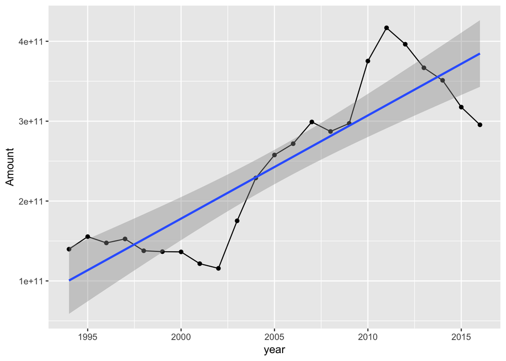

```r
colnames(gdp)<-c('year','Amount')
ggplot(gdp[35:57,],aes(year,Amount))+
  geom_path()+
geom_point()+
  geom_smooth(method = lm)
```

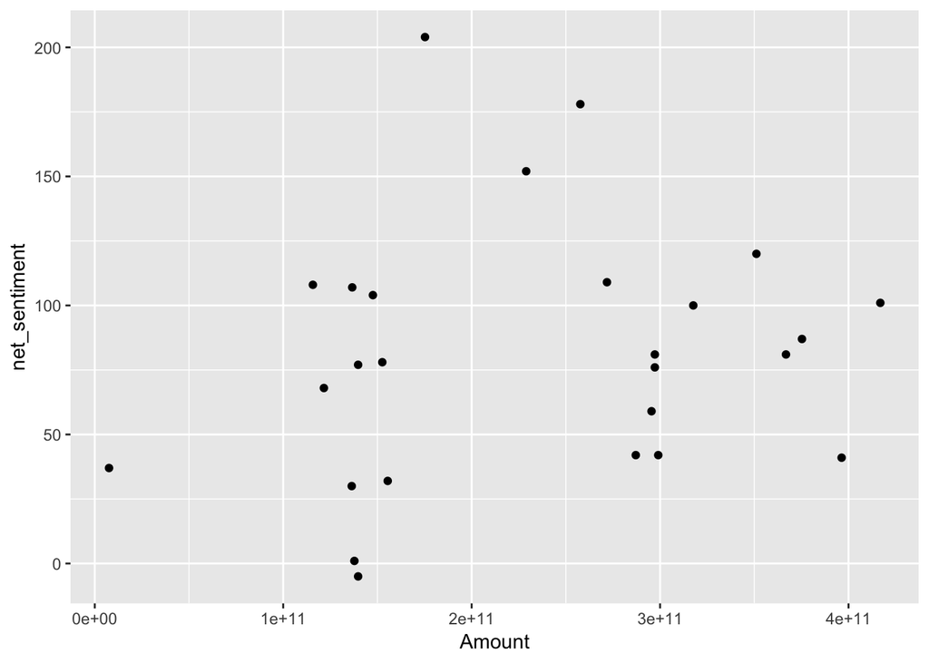

```r
PLOT2<-ggplot(sona, aes(cur_sent_sona$year,cur_sent_sona$net_sentiment,shape=pres_name, color=pres_name,group = 1)) +
  geom_path() +
  geom_point()
cur_sent_sona<-data.table(cur_sent_sona)
sentiments_per_sona<-data.table(sentiments_per_sona)
gdp$year<-as.character(gdp$year)
this_set<-gdp[sentiments_per_sona, on = 'year']

ggplot(this_set,aes(Amount,net_sentiment))+
  geom_point()
```

As can be seen for the plots, the correlation between the GDP and SONA is non existing , which either points to that the GDP is not a good indicator the the positivity/negativity of a country or the SONA’s are over inflated with positivity.